# HW8-ADA

# Jing Qian (jq2282)

#### 1.a. Find the density, $f_T(t)$ of $T$.

$f_T(t) = -\frac{d}{d\ t}S(t) = \alpha^{\beta}\beta\ t^{\beta-1} e^{-(\alpha t)^{\beta}}$.

#### 1.b. Find the hazard function $\lambda(t)$ of $T$.

$\lambda (t) = \frac{f_T(t)}{S(t)} = \frac{\alpha^{\beta}\beta\ t^{\beta-1} e^{-(\alpha t)^{\beta}}}{e^{-(\alpha t)^{\beta}}} = \alpha^{\beta}\beta\ t^{\beta-1}$.

#### 1.c. Show that $\log(−\log(S(t))) = \beta \log(\alpha) + \beta \log(t)$. Based on this, describe a graphical method for checking whether or not the data is from a Weibull distribution.

Since $S(t) = e^{-(\alpha t)^{\beta}}$, $−\log(S(t)) = (\alpha t)^{\beta}$.

Then $\log(−\log(S(t))) = \log((\alpha t)^{\beta}) = \beta \log(\alpha t) = \beta(\log \alpha + \log t) = \beta \log(\alpha) + \beta \log(t)$.

Based on the proved equation, we could use a log-log plot to check whether the data is from a Weibull distribution. Check whether the data fits a linear function $Y = m X + b$ in the log-log plot, in which $Y = \log(−\log(S(t)))$, $m = \beta$, $X = \log t$ and $b = \beta \log(\alpha)$. If the data shows linearity in the log-log plot, it is from a Weibull distribution.

#### 1.d. Use the graphical technique in the previous question to check if a Weibull distribution is appropriate for these data.

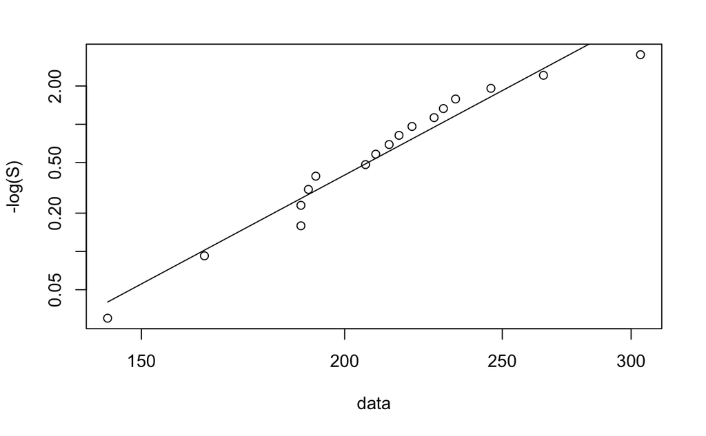

```r
data<-c(143, 164, 188, 188, 190, 192, 206, 209, 213, 216, 220, 227, 230, 234, 246, 265, 304)
sE<-numeric(0)
for (i in 1:length(data)){
  sE[i] = 1-(i-0.5)/length(data)}
y = -log(sE)
plot(data, y, log="xy", xlab="data", ylab="-log(S)")
reg=lm(log(y)~log(data))
lines(data,exp(predict(reg)))
```

From the plot above, we could see that $-\log(\hat{S}(t))$ and $t$ shows linearity in the log-log plot. As we proved in the previous question, linearity in the log-log plot shows that these data fit a Weibull distribution.

#### 1.e. Assume that the Weibull distribution is a good fit, use least squares approach to estimate its parameters.

```r
summary(reg)
```

```
Call:
lm(formula = log(y) ~ log(data))

Residuals:
     Min       1Q   Median       3Q      Max
-0.68997 -0.12226  0.09174  0.19153  0.30116

Coefficients:
            Estimate Std. Error t value Pr(>|t|)
(Intercept) -37.2330     2.1806  -17.07 3.08e-11 ***
log(data)     6.8538     0.4073   16.83 3.80e-11 ***
---
Signif. codes:  0 ‘***’ 0.001 ‘**’ 0.01 ‘*’ 0.05 ‘.’ 0.1 ‘ ’ 1

Residual standard error: 0.2871 on 15 degrees of freedom
Multiple R-squared:  0.9497,    Adjusted R-squared:  0.9463
F-statistic: 283.1 on 1 and 15 DF,  p-value: 3.796e-11
```

As shown in the previous question, we use the least squares linear regression in the plot to show the linearity in the log-log plot. The estimated parameters for fitted $Y=mX+b$ are: $b$ = -37.233 and $m$ = 6.854. As we showed in 1.c, $m = \beta$ and $b = \beta \log(\alpha)$. So $\beta = m = 6.854$, $\alpha = e^{b/\beta} = 0.004$.

#### 2.a. Obtain and plot the Kaplan Meier estimates of $S_A$ and $S_B$, the corresponding survival functions.

```r
library(survival)
xA<-c(1.25, 1.41, 4.98, 5.25, 5.38, 6.92, 8.89, 10.98, 11.18, 13.11, 13.21, 16.33, 19.77, 21.08, 21.84, 22.07, 31.38, 32.61, 37.18, 42.92)
deltaA<-c(rep(1,14), 0, 1, rep(0,3),1)
kmA<-survfit(Surv(xA,deltaA)~1, type="kaplan-meier")
print(kmA$surv)
```

```
 [1] 0.95 0.90 0.85 0.80 0.75 0.70 0.65 0.60 0.55 0.50 0.45 0.40 0.35 0.30 0.30 0.24
[17] 0.24 0.24 0.24 0.00
```

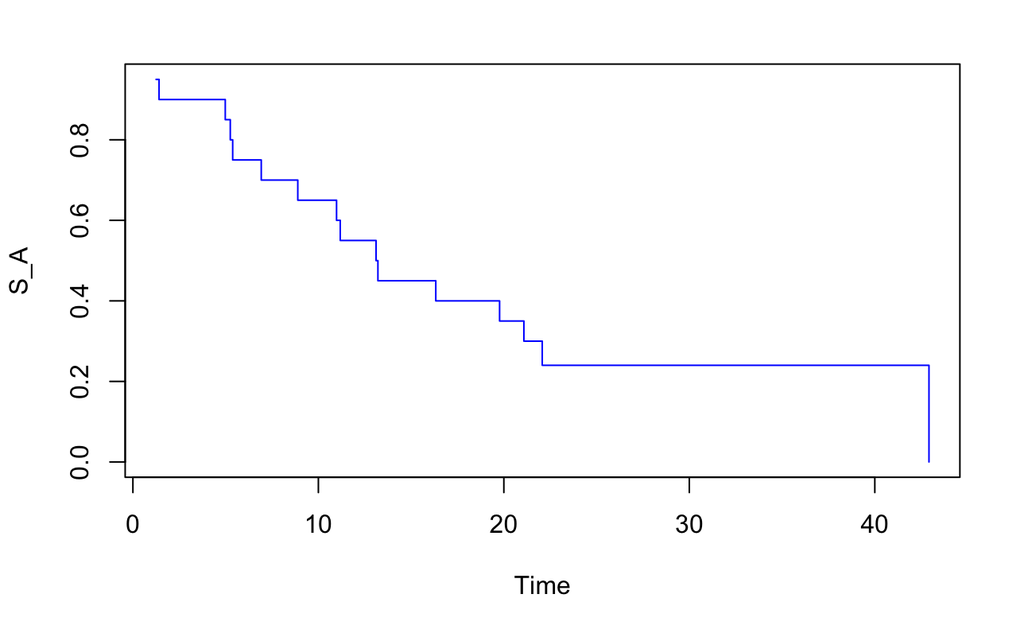

```r
plot(kmA$time, kmA$surv, type="s", col='blue',xlab="Time", ylab="S_A")
```

```r
xB<-c(1.05, 2.92, 3.61, 4.20, 4.49, 6.72, 7.31, 9.08, 9.11, 14.49, 16.85, 18.82, 26.59, 30.26, 41.34)
deltaB<-c(rep(1,9), 0, 1, rep(0,4))
kmB<-survfit(Surv(xB,deltaB)~1, type="kaplan-meier")
print(kmB$surv)
```

```
 [1] 0.9333333 0.8666667 0.8000000 0.7333333 0.6666667 0.6000000 0.5333333 0.4666667
 [9] 0.4000000 0.4000000 0.3200000 0.3200000 0.3200000 0.3200000 0.3200000
```

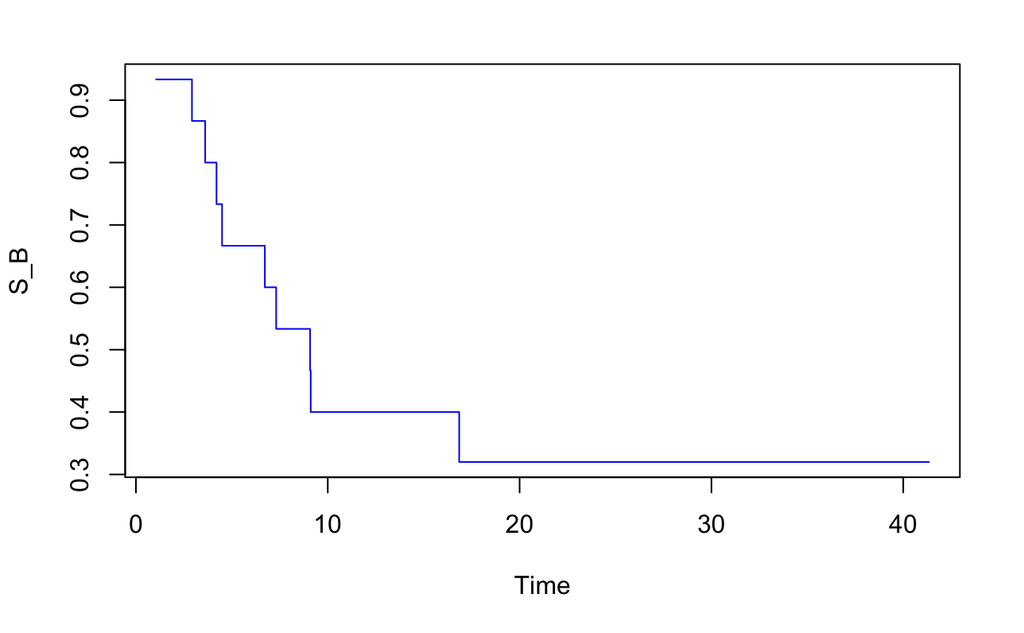

```r
plot(kmB$time, kmB$surv, type="s", col='blue',xlab="Time", ylab="S_B")
```

From above, we could see that Kaplan Meier estimates for $S_A$ at given time are: (0.95, 0.90, 0.85, 0.80, 0.75, 0.70, 0.65, 0.60, 0.55, 0.50, 0.45, 0.40, 0.35, 0.30, 0.30, 0.24, 0.24, 0.24, 0.24, 0.00). Kaplan Meier estimates for $S_B$ at given time are: (0.9333333, 0.8666667, 0.8, 0.7333333, 0.6666667, 0.6, 0.5333333, 0.4666667, 0.4, 0.4, 0.32, 0.32, 0.32, 0.32, 0.32).

#### 2.b. Estimate $S_A$(10) and $S_B$(10) using a 95% confidence interval.

```r
summary(kmA)
```

```
Call: survfit(formula = Surv(xA, deltaA) ~ 1, type = "kaplan-meier")

  time n.risk n.event survival std.err lower 95% CI upper 95% CI
  1.25     20       1     0.95  0.0487        0.859        1.000
  1.41     19       1     0.90  0.0671        0.778        1.000
  4.98     18       1     0.85  0.0798        0.707        1.000
  5.25     17       1     0.80  0.0894        0.643        0.996
  5.38     16       1     0.75  0.0968        0.582        0.966
  6.92     15       1     0.70  0.1025        0.525        0.933
  8.89     14       1     0.65  0.1067        0.471        0.897
 10.98     13       1     0.60  0.1095        0.420        0.858
 11.18     12       1     0.55  0.1112        0.370        0.818
 13.11     11       1     0.50  0.1118        0.323        0.775
 13.21     10       1     0.45  0.1112        0.277        0.731
 16.33      9       1     0.40  0.1095        0.234        0.684
 19.77      8       1     0.35  0.1067        0.193        0.636
 21.08      7       1     0.30  0.1025        0.154        0.586
 22.07      5       1     0.24  0.0980        0.108        0.534
 42.92      1       1     0.00     NaN           NA           NA
```

From the output above, we could see that the 95% confidence interval for $S_A(10) = [0.471, 0.897]$.

```r
summary(kmB)
```

```
Call: survfit(formula = Surv(xB, deltaB) ~ 1, type = "kaplan-meier")

  time n.risk n.event survival std.err lower 95% CI upper 95% CI
  1.05     15       1    0.933  0.0644        0.815        1.000
  2.92     14       1    0.867  0.0878        0.711        1.000
  3.61     13       1    0.800  0.1033        0.621        1.000
  4.20     12       1    0.733  0.1142        0.540        0.995
  4.49     11       1    0.667  0.1217        0.466        0.953
  6.72     10       1    0.600  0.1265        0.397        0.907
  7.31      9       1    0.533  0.1288        0.332        0.856
  9.08      8       1    0.467  0.1288        0.272        0.802
  9.11      7       1    0.400  0.1265        0.215        0.743
 16.85      5       1    0.320  0.1239        0.150        0.684
```

From the output above, we could see that the 95% confidence interval for $S_B(10) = [0.215, 0.743]$.